# Visualizing Genomics Data in Bioconductor exercises

Rockefeller University, Bioinformatics Resource Centre

https://rockefelleruniversity.github.io/Bioconductor_Introduction/

In this practical we will be reviewing some of methods for visualising and clustering data from RNAseq data.

In todays session we will continue to review the Tissue RNAseq we were working on in our last sessions.

- More information on liver data [can be found here](https://www.encodeproject.org/experiments/ENCSR000CHB/)
- More information on heart data [can be found here](https://www.encodeproject.org/experiments/ENCSR000CGZ/)
- More information on Kidney data [can be found here](https://www.encodeproject.org/experiments/ENCSR000CGZ/)

Preprocessed counts for Tissue data for this practical session can be found in the **Data** directory. **Data/tissueCounts.RData**

- Load in the DESeq2 object for Tissues experiment, produce a rlog transformation and plot the PCA for these genes.

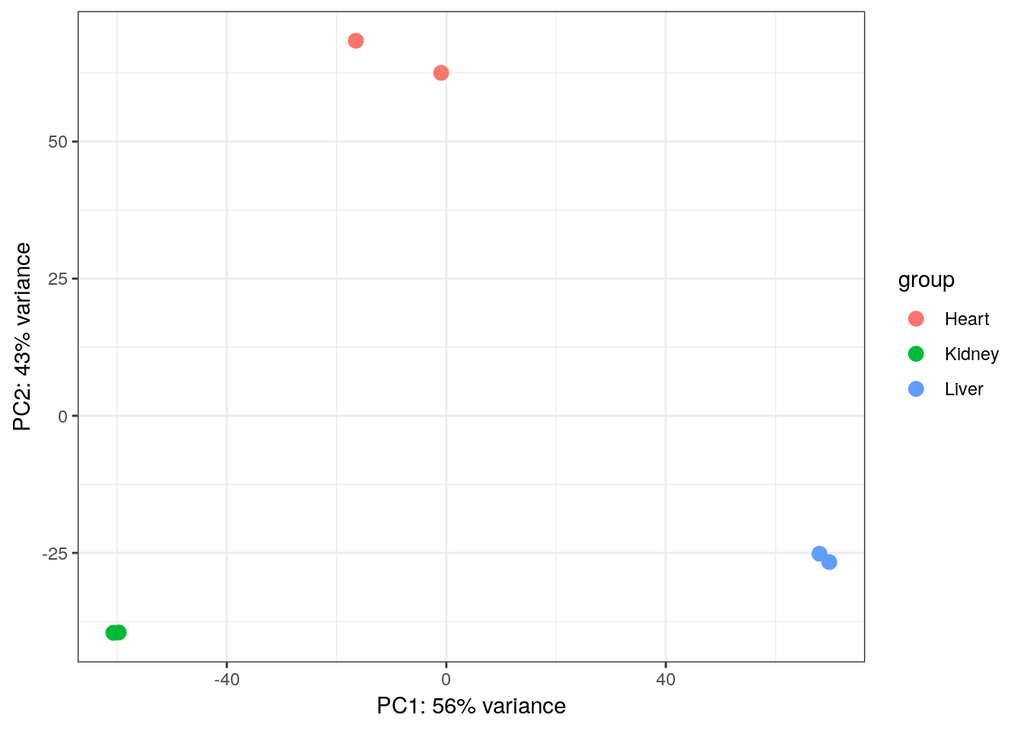

- Filter to genes significant (padj < 0..01) from our LRT test between all groups and produce a heatmap.

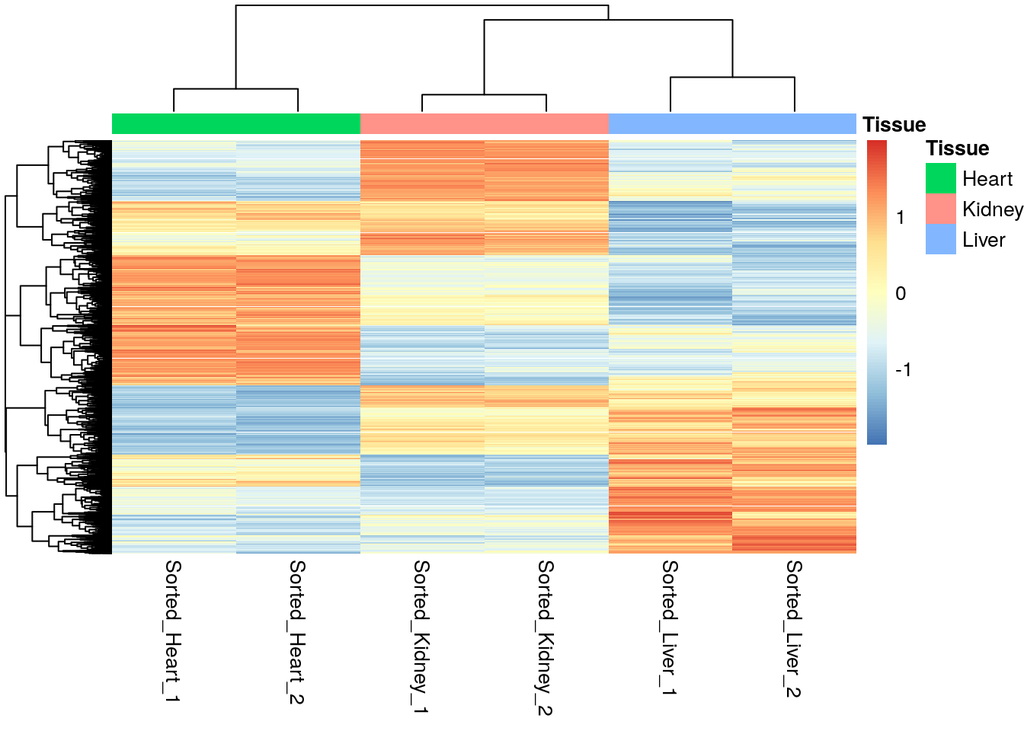

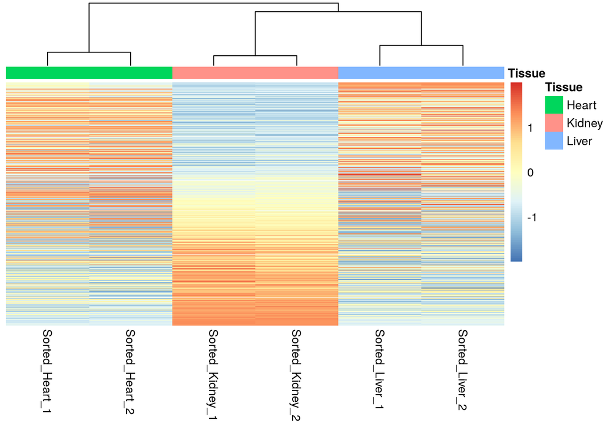

- Produce a PCA plot of the GO “heart development” genes. You can check [QuickGO webbsite to find its ID](https://www.ebi.ac.uk/QuickGO/.)

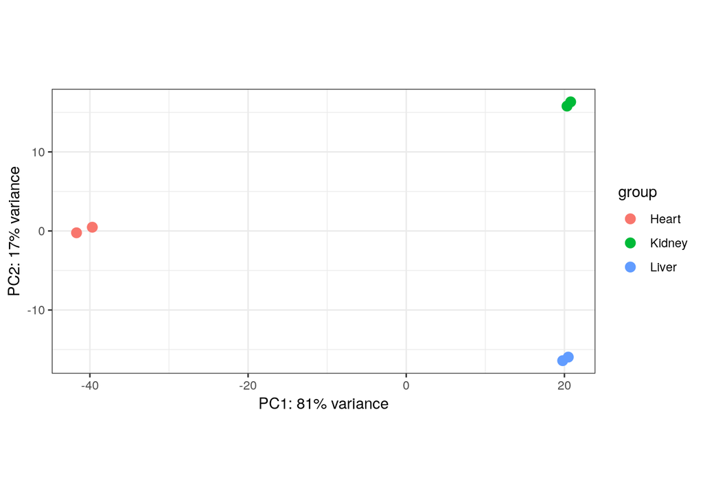

- Create a Heatmap of all genes and include row annotation showing members of heart development, liver development and kidney development GO set.

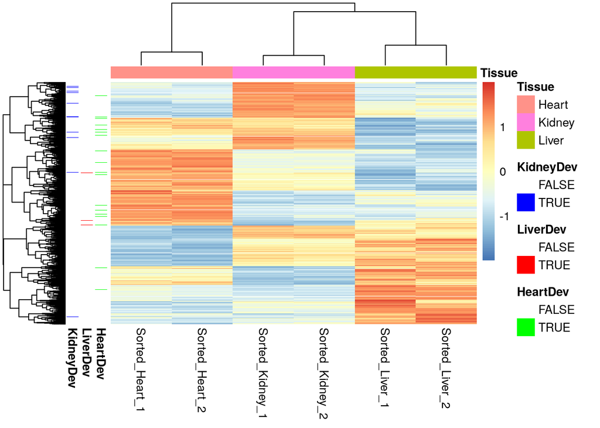

- Import the replicated peaks for H3k27ac and H3K4me3 for Heart tissue samples found in Data directory. Identify genes with both H3k4me3 and H3k27ac peaks in their TSS (+/-500bp).
- H3k4me3 = **Data//ENCFF599BFW.bed.gz**
- H3k27ac = **Data//ENCFF733HUI.bed.gz**
- Create a heatmap of the top 100 marker (both positive and negative) for PC1 and add annotation for genes with H3k27ac and H3K4me3 peaks in their TSS.

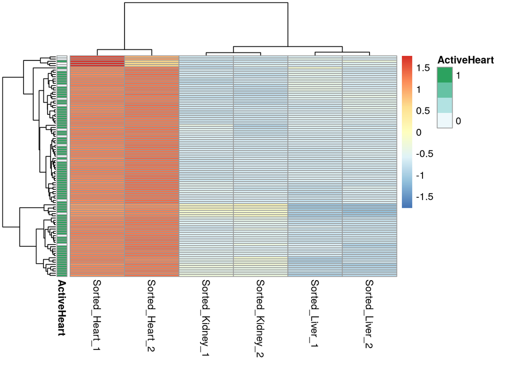

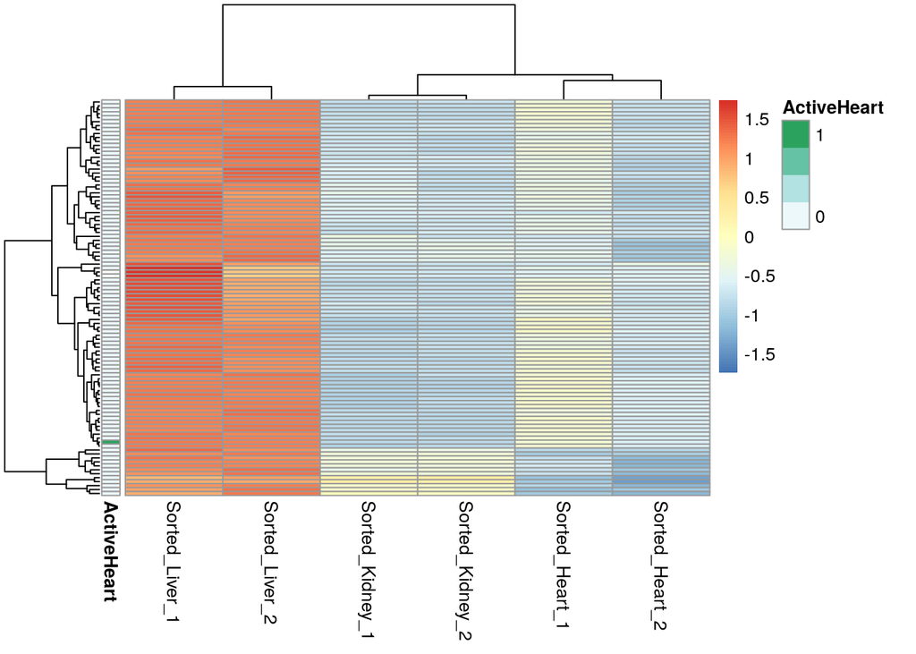